# Ventas Videojuegos

1 de Junio del 2023

# Índice:

1. Introducción
   1. Tema
   2. Relevancia
   3. Objetivos
      1. Objetivos Generales
      2. Objetivos Específicos
   4. Contexto
2. Datos
   1. Recolección de datos
   2. Población, muestra y muestreo
   3. Variables
3. Análisis Descriptivo
4. Probabilidades
   1. Probabilidad empírica
   2. Probabilidad condicional
5. Variables
   1. Variables discretas
   2. Variables continuas

## 1. Introducción

### 1.1 Tema

Análisis de las ventas en la industria de videojuegos comprendidos entre los años 2015 a 2016 mediante una base de datos.

### 1.2 Relevancia

Como en la industria de videojuegos en la actualidad genera casi lo mismo o más que la industria de cine y la música actualmente , por ello hemos visto convenientes que las inversora de la industrias de videojuegos puedan saber a qué sector invertir para obtener las mayoras ganancias posibles en las diversa regiones de Europa ,América, países como Japón entre otros con el fin de que estas pueden tener gustos diferentes o similares , también de conocer los riesgos en estos mercados y saber el con que desarrolladora y distribuidora contar. Además de tener en cuenta las críticas de los videojuegos pública y profesional, la calificaciones de edad y los tipos de juegos mas demandado .Por ello, hemos analizado los juegos lanzados de 2015 a 2016 para tener una idea de como fue el mercado durante este tiempo para conocer los éxitos y fracasos que hubo.

### 1.3 Objetivos

- Es importante tener un objetivo claro antes de comenzar el análisis para garantizar que el análisis sea relevante y útil.

#### 1.3.1 Objetivos Generales

- Determinar cuáles fueron las categorías de los juegos más vendidos además como influye en el desarrollo de la industria de los videojuegos.
- Comparar las ventas de videojuegos en diferentes regiones geográficas y determinar las diferencias en los patrones de compra de los consumidores. Predecir las ventas futuras de videojuegos en la industria utilizando modelos estadísticos y de aprendizaje automático.

#### 1.3.2 Objetivos Específicos

- Examinar los videojuegos por país (Europa,Norteamérica y Japón )
- Analizar cuáles fueron los distribuidores de videojuegos con más publicaciones.
- Precisar que desarrolladora de videojuegos fue la más demandante.
- Identificar patrones y tendencias de venta en la industria de los videojuegos entre 2015 y 2016, incluyendo los géneros de videojuegos más populares y las plataformas de juegos más utilizadas.
- Analisar que plataformas de videojuegos dominaron mas en el año 2015 y 2016, a su vez en que año dichas plataformas tuvieron mas demandas.
- Tendencias de clasificaciones de edad por género de videojuego.

### 1.4 Contexto

El análisis de las ventas en la industria de videojuegos entre los años 2015 y 2016 es de gran relevancia para comprender el desempeño y las tendencias del mercado en este sector en constante evolución. A través de una base de datos específica, se busca examinar y entender las ventas en esta industria durante ese período.

La industria de los videojuegos ha experimentado un crecimiento significativo en las últimas décadas, convirtiéndose en una forma de entretenimiento popular y altamente lucrativa a nivel mundial. El análisis de las ventas en este sector proporciona información crucial sobre los patrones de consumo, las preferencias de los jugadores y el éxito de los diferentes títulos y géneros de videojuegos.

Con el análisis de las ventas de videojuegos entre 2015 y 2016, se pretende identificar patrones de ventas, explorar relaciones entre variables relevantes y examinar las tendencias de consumo de videojuegos durante ese período específico.

## 2. Datos

La base de datos proporcionada contiene información detallada, como el nombre del videojuego, la plataforma, el año de lanzamiento, el género, el editor, las ventas en diferentes regiones, las ventas globales, las puntuaciones de los críticos y usuarios, la cantidad de críticas y usuarios, el desarrollador y la clasificación por edad recomendada (“Rating”).

### 2.1 Recolección de datos

La página web de donde fue sacada la información de datos fue la siguiente: **“kaggle.com”**

Para nuestros instrumentos de recolección nos basamos en los siguientes criterios:

- La reputación de la fuente: La fuente es conocida por ser confiable y precisa, es por ello que lo más probable es que sus datos sean confiables. Ademas de que fue recomendada por el profesor.
- Esta base de datos tiene información acerca de los juegos descargados desde los años 1980 hasta el 2016, nosotros resumimos la base de datos para analizarlo desde el 2015 hasta 2016 esto con el fin de tener datos más actualizados.

Para ser precisos la base de datos descargado lo encontramos en el siguiente link:: “https://www.kaggle.com/datasets/gregorut/videogamesales”

### 2.2 Población, muestra y muestreo

Población:

La población es 16 598 registros de videojuegos con la condición de que tengan en común lograr superar las 100 000 copias

### 2.3 Variables

Para realizar el estudio hemos contado con las siguientes variables.

[output not shown]

### 2.4 Limpieza de Datos

- Hemos utilizado la función *deleate.na* para eliminar las filas que no tengan data.

```r
library(dplyr)
getwd()
```

```
## [1] "D:/Anthony_Trabajo/UTEC/Documentos - 2023-1/Seccion 3/Nota Alta/202310301-Ventas Videojuegos/Informe 2"
```

```r
juegos=read.csv("juegos.csv")


delete.na <- function(df, n=0) {  #ELIMINAR LAS FILAS QUE NO TENGAN DATA
 df[rowSums(is.na(df)) <= n,]

}
```

```r
juegos_sin_0 = delete.na(juegos)
```

- Como tenemos datos muy antiguos nosotros nos hemos especificado entre los años 2015-2016.
- Luego asignamos estos nuevos datos a la nueva variable *juegos2015_2016*.

```r
juegos2015_2016=juegos_sin_0[juegos_sin_0$Year_of_Release >= 2015 & juegos_sin_0$Year_of_Release <= 2017 , ] ##quedarme solo con los años 2015 a 106
juegos2015_2016 <- subset(juegos2015_2016, !Rating == "" )
juegos2015_2016
```

|  | Name | Platform | Year_of_Release | Genre | Publisher | NA_Sales | EU_Sales | JP_Sales | Other_Sales | Global_Sales | Critic_Score | Critic_Count | User_Score | User_Count | Developer | Rating | Columna1 | Columna2 |
| --- | --- | --- | --- | --- | --- | --- | --- | --- | --- | --- | --- | --- | --- | --- | --- | --- | --- | --- |
| 78 | FIFA 16 | PS4 | 2015 | Sports | Electronic Arts | 1.12 | 6.12 | 0.06 | 1.28 | 8.57 | 82 | 42 | 4.3 | 896 | EA Sports | E |  |  |
| 95 | FIFA 17 | PS4 | 2016 | Sports | Electronic Arts | 0.66 | 5.75 | 0.08 | 1.11 | 7.59 | 85 | 41 | 5 | 398 | EA Sports, EA Vancouver | E |  |  |
| 106 | Fallout 4 | PS4 | 2015 | Role-Playing | Bethesda Softworks | 2.53 | 3.27 | 0.24 | 1.13 | 7.16 | 87 | 58 | 6.5 | 4228 | Bethesda Game Studios | M |  |  |
| 172 | Uncharted 4: A Thief's End | PS4 | 2016 | Shooter | Sony Computer Entertainment | 1.85 | 2.5 | 0.19 | 0.85 | 5.38 | 93 | 113 | 7.9 | 7064 | Naughty Dog | T |  |  |
| 232 | Uncharted: The Nathan Drake Collection | PS4 | 2015 | Action | Sony Computer Entertainment | 2.07 | 1.71 | 0.08 | 0.76 | 4.62 | 86 | 78 | 8.1 | 1264 | Bluepoint Games | T |  |  |
| 243 | Halo 5: Guardians | XOne | 2015 | Shooter | Microsoft Game Studios | 2.78 | 1.27 | 0.03 | 0.41 | 4.48 | 84 | 101 | 6.4 | 2438 | 343 Industries | T |  |  |
| 246 | Call of Duty: Infinite Warfare | PS4 | 2016 | Shooter | Activision | 1.61 | 2 | 0.15 | 0.71 | 4.46 | 77 | 82 | 3.4 | 1129 | Infinity Ward | M |  |  |
| 248 | Splatoon | WiiU | 2015 | Shooter | Nintendo | 1.54 | 1.18 | 1.46 | 0.26 | 4.43 | 81 | 88 | 8.5 | 1184 | Nintendo | E10+ |  |  |
| 271 | Fallout 4 | XOne | 2015 | Role-Playing | Bethesda Softworks | 2.51 | 1.32 | 0.01 | 0.38 | 4.22 | 88 | 39 | 6.2 | 1749 | Bethesda Game Studios | M |  |  |
| 290 | Battlefield 1 | PS4 | 2016 | Shooter | Electronic Arts | 1.1 | 2.15 | 0.21 | 0.61 | 4.08 | 88 | 31 | 8.4 | 809 | EA DICE | M |  |  |

[output cut: 417 more lines]

```r
#Algunas variables no estaban clasificadas correctamente, debido a esto, se tuvo que cambiarlas al tipo de variable que pertenecían.
# Convertir las columnas de ventas a tipo numérico
juegos2015_2016$NA_Sales <- as.numeric(juegos2015_2016$NA_Sales)
juegos2015_2016$EU_Sales <- as.numeric(juegos2015_2016$EU_Sales)
juegos2015_2016$JP_Sales <- as.numeric(juegos2015_2016$JP_Sales)
juegos2015_2016$Other_Sales <- as.numeric(juegos2015_2016$Other_Sales)
```

## 3. Análisis descriptivo

### Comparar las ventas en diferentes regiones con el género de videojuego: *North America*

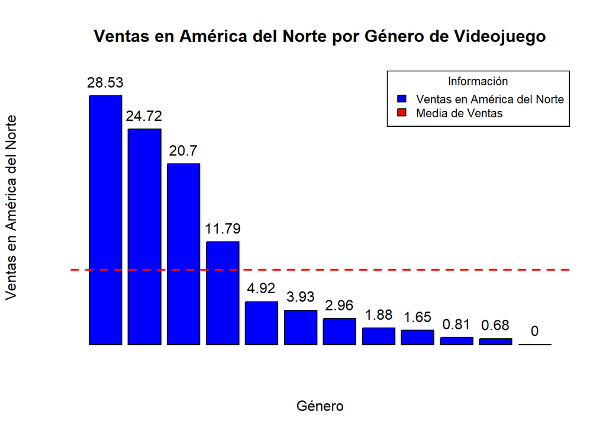

```r
# Filtrar solo para la región de América del Norte
ventas_NA <- juegos2015_2016[, c("Genre", "NA_Sales")]

# Sumar las ventas por género
ventas_NA <- aggregate(NA_Sales ~ Genre, data = ventas_NA, FUN = sum)

# Ordenar los géneros por ventas en América del Norte
ventas_NA <- ventas_NA[order(ventas_NA$NA_Sales, decreasing = TRUE), ]


# Añadir etiquetas
text(x = barplot(ventas_NA$NA_Sales,
                 col = "blue",
                 ylim = c(0, max(ventas_NA$NA_Sales) * 1.1),
                 axes = FALSE,
                 main = "Ventas en América del Norte por Género de Videojuego",
                 xlab = "Género",
                 ylab = "Ventas en América del Norte"),
     y = ventas_NA$NA_Sales,
     labels = ventas_NA$NA_Sales,
     pos = 3,
     col = "black")

# Añadir una línea de referencia para la media de ventas
abline(h = mean(ventas_NA$NA_Sales),
       col = "red",
       lwd = 2,
       lty = 2)

# Agregar una leyenda
legend("topright",
       legend = c("Ventas en América del Norte", "Media de Ventas"),
       fill = c("blue", "red"),
       title = "Información",
       cex = 0.8)
```

Lo que podemos concluir es que los géneros de videojuegos que dominan en América del Norte , son primero **“shooters”**(Juegos de disparos), segundo juegos de **“Acción”**, tercero juegos de **“Deportes”** y cuarto juegos de **“rol”** ,según los juegos que superan la línea de media.

Estos datos son muy útiles ya que las empresa sabrán en qué tipo de juegos valen la pena invertir grandes cantidades con el objetivo de obtener ganancias en América del Norte.

### Tabla de ventas totales en cada región

```r
# Agrupar y sumar las ventas por región
ventas_totales <- aggregate(cbind(NA_Sales, EU_Sales, JP_Sales, Other_Sales) ~ 1, data = juegos2015_2016, FUN = sum)
colnames(ventas_totales) <- c("Ventas totales en Norte America", "Ventas totales en Europa", "Ventas totales en Japon", "Ventas totales en Otras regiones")

# Ordenar los totales de ventas de mayor a menor
ventas_totales <- ventas_totales[order(ventas_totales$`Ventas totales en Norte America` + ventas_totales$`Ventas totales en Europa` + ventas_totales$`Ventas totales en Japon` + ventas_totales$`Ventas totales en Otras regiones`, decreasing = TRUE), ]

# Tabla de totales de ventas
ventas_totales
```

|  | Ventas totales en Norte America | Ventas totales en Europa | Ventas totales en Japon | Ventas totales en Otras regiones |
| --- | --- | --- | --- | --- |
| 1 | 102.57 | 101.74 | 16.09 | 30.5 |

Algunas formas en las que esta tabla podría ser útil en el estudio incluyen: .Comparación de ventas por región .Identificación de patrones por región .Tabla de ventas por región, lo que puede ayudar a comprender mejor el mercado y tomar decisiones informadas en tu estudio o análisis relacionado con los videojuegos.

### Identificar patrones y tendencias de venta en la industria de los videojuegos entre 2015 y 2016, incluyendo los géneros de videojuegos más populares y las plataformas de juegos más utilizadas.

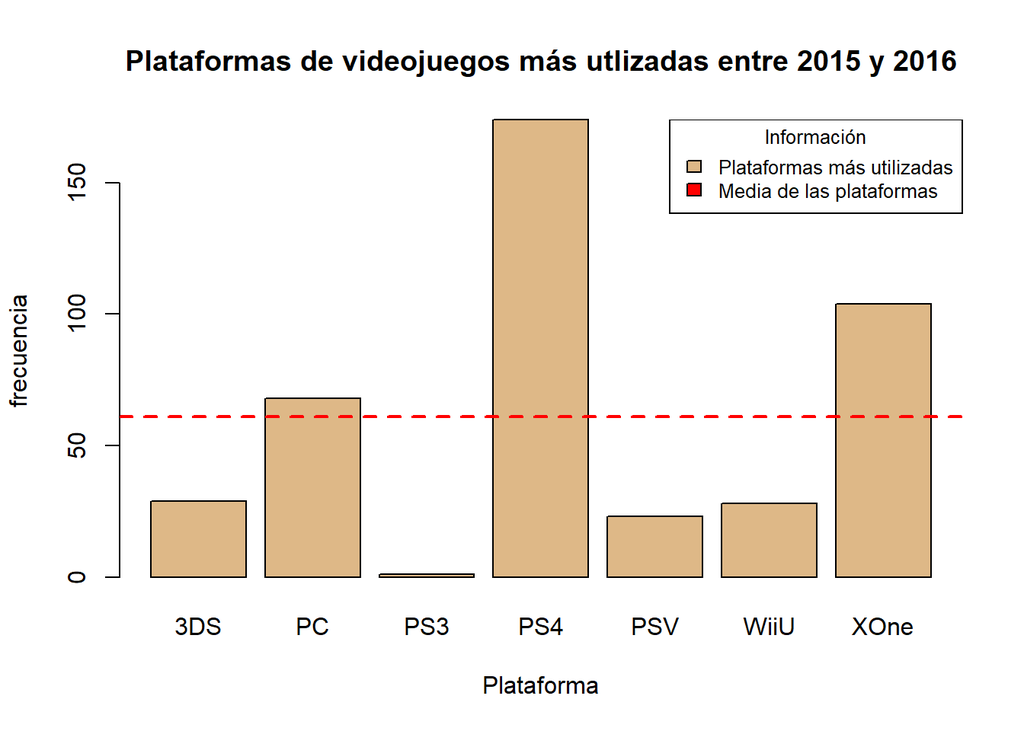

```r
#Tendencia de las Plataformas más utilizadas


cantidad_plat <- table(juegos2015_2016$Platform) #Cantidad de plataformas utilizadas en los videojuegos

barplot(cantidad_plat,col="burlywood",main = "Plataformas de videojuegos más utlizadas entre 2015 y 2016",xlab = "Plataforma",ylab ="frecuencia")

legend("topright",
       legend = c("Plataformas más utilizadas","Media de las plataformas"),
       fill = c("burlywood","red"),
       title = "Información",
       cex = 0.8)

abline(h = mean(cantidad_plat),
       col = "red",
       lwd = 2,
       lty = 2)
```

análisis: . útil para desarrolladoras de videojuegos, para saber a qué plataforma conviene adaptar su producto. . No conviene adaptar en la Ps3 . Conviene adaptar juegos a Ps4, XOne y PC

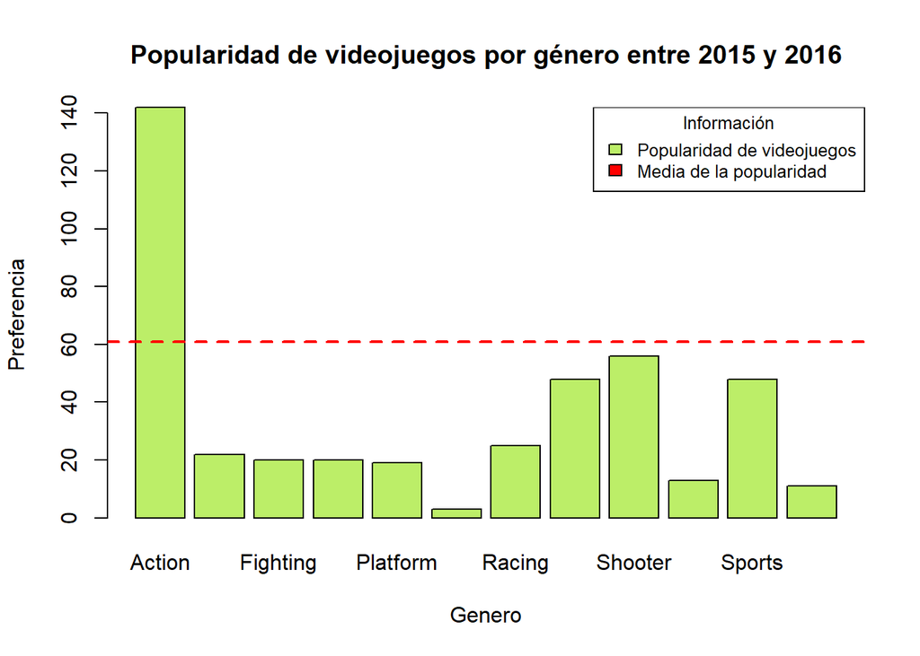

```r
#Tendencia de los generos más populares

cantidad_gen <- table(juegos2015_2016$Genre)
barplot(cantidad_gen,col="darkolivegreen2",main = "Popularidad de videojuegos por género entre 2015 y 2016",xlab = "Genero",ylab ="Preferencia")

legend("topright",
       legend = c("Popularidad de videojuegos","Media de la popularidad"),
       fill = c("darkolivegreen2","red"),
       title = "Información",
       cex = 0.8)

abline(h = mean(cantidad_plat),
       col = "red",
       lwd = 2,
       lty = 2)
```

En esta gráfica nos muestra en general se puede concluir que la popularidad es más en el genéro **Action** y menos en **Puzzle**. .

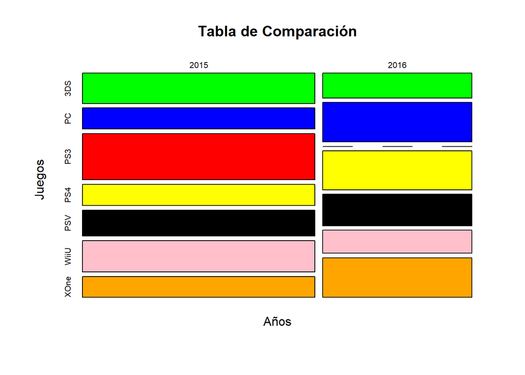

```r
#Comparacion en que año las plataformas de videojuegos tuvieron mas demanda.
Tabla_Comparacion_2 = prop.table(table(juegos2015_2016$Year_of_Release,juegos2015_2016$Platform), margin = 2)*100

mosaicplot(Tabla_Comparacion_2 ,main = "Tabla de Comparación",xlab = "Años",ylab = "Juegos",color = c("green","blue","red","yellow","black","pink","orange"))
```

Resumen del análisis.

1. Los juegos que dominaron mas en el año 2015 y 2016 fueron la PC, el PS4 y el XOne.
2. Algunas plataformas que disminuyeron su demanda para el año 2016 fueron: 3DS, PSV y WiiU, y las otras plataformas como: PC, PS4 y XOne aumentaron.
3. Finalmente las PS3 bajo su demanda drasticamente para el año 2016.

### Puntuación promedio por cada Género

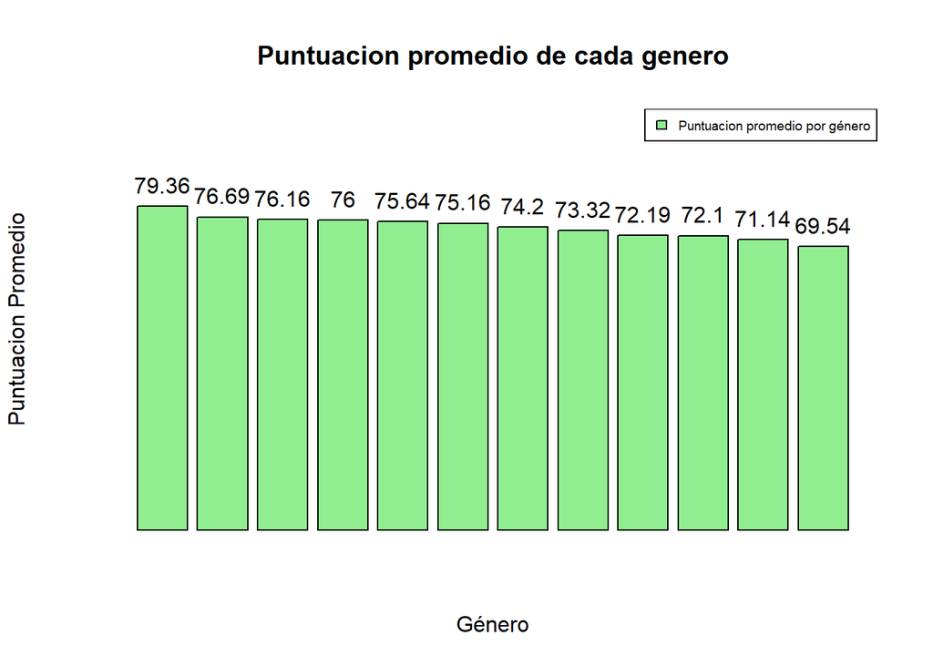

```r
#Separamos la data que usaremos
genero <- juegos2015_2016[, c("Genre", "Critic_Score")]
#Promedio para cada genero
genero_promediado <- aggregate(Critic_Score ~ Genre, data = genero, FUN = mean)

genero_promediado <- genero_promediado[order(genero_promediado$Critic_Score, decreasing = TRUE), ]
#Redondeamos
genero_promediado$Critic_Score <- round(genero_promediado$Critic_Score,2)
#Graficamos

text(x = barplot(genero_promediado$Critic_Score,

                 col = "light green",
                 ylim = c(0, max(genero_promediado$Critic_Score) * 1.3),
                 axes = FALSE,
                 main = "Puntuacion promedio de cada genero",
                 xlab = "Género",
                 ylab = "Puntuacion Promedio"),
     y = genero_promediado$Critic_Score,
     labels = genero_promediado$Critic_Score,
     pos = 3,
     col = "black")
legend("topright",
       legend = c("Puntuacion promedio por género"),
       fill = c("light green"),
       cex = 0.6)
```

Al realizar este análisis podemos ver en la gráfica no hay mucha variación en la puntuación, pero también podemos deducir cuales son los 3 primeros géneros que llaman más la atención de la población, por ende podemos aumentar el número de videojuego en el mercado variando el tipo entre estos tres géneros.También con esta información les servirá a los creadores a mejorar la calidad de los videojuegos.

### Tendencias de clasificaciones de edad por género de videojuego

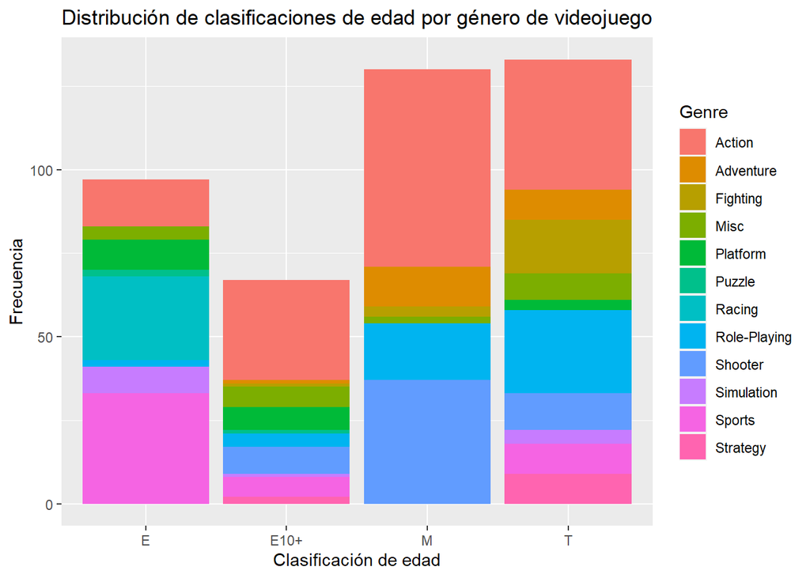

```r
library(ggplot2)
ggplot(juegos2015_2016, aes(x = Rating, fill = Genre)) +
  geom_bar() +
  labs(x = "Clasificación de edad", y = "Frecuencia", title = "Distribución de clasificaciones de edad por género de videojuego")
```

Este tipo de gráfico brinda una visión general de cómo se distribuyen las clasificaciones de edad en cada género de videojuegos. Se puede observar las diferencias relativas entre los géneros y determinar si hay géneros específicos que tienden a tener ciertas clasificaciones de edad con más frecuencia.

## 4. Probabilidades

### 4.1 Probabilidad empírica

ejemplo 1 1) Experimento: Seleciona un juego y observa de que plataforma pertenece 2)Experimento resultado

```r
table(juegos2015_2016$Platform)
```

```
##
##  3DS   PC  PS3  PS4  PSV WiiU XOne
##   29   68    1  174   23   28  104
```

u =[3ds, pc, ps3.ps4,psv,wiiu yxbox one] 3) Identificar evento A1 : Selecionar un juego que sea 3ds A2: Selecionar un juego que sea PS3 A3: Selecionar un juego que sea PS4 A4: Selecionar un juego que sea PSV A5: Selecionar un juego que sea WIIU A6: Selecionar un juego que sea XONE

4)Probabilidades Hallamos las probabilidades de cada evento representado en una grafica y tabla

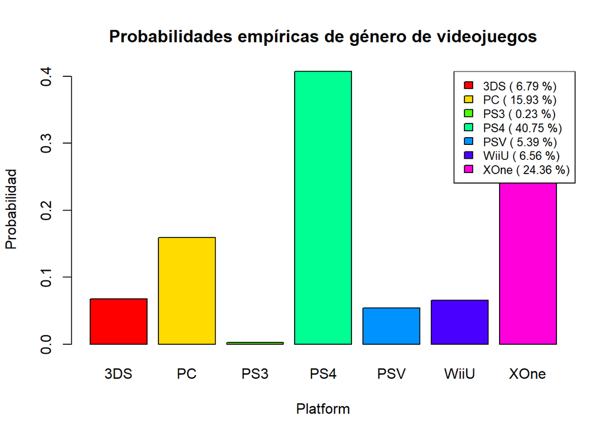

```r
# Calcular las probabilidades empíricas para la variable "Genre"
probabilidades_genre <- prop.table(table(juegos2015_2016$Platform))
generos <- names(probabilidades_genre)

# gráfico de barras para las probabilidades empíricas de "Genre"
barplot(probabilidades_genre, main = "Probabilidades empíricas de género de videojuegos", xlab = "Platform", ylab = "Probabilidad", col = rainbow(length(probabilidades_genre)), names.arg = generos)

# Leyenda
legend("topright", legend = paste(generos, "(", round(probabilidades_genre * 100, 2), "%)"), fill = rainbow(length(probabilidades_genre)), cex = 0.8)
```

Experimento de plataforma de vidiojuego omega[3ds pc ps3 ps4 psv wiiu xones]

La probabilidad empírica es una medida descriptiva que permite observar las tendencias y patrones de frecuencia en los datos. Al comparar las probabilidades empíricas de diferentes géneros, se pueden identificar los géneros más prevalentes en la muestra y comprender la distribución relativa de los géneros de videojuegos en el período analizado.

ejemplo 2 empirica

1. Experimento: Seleciona un juego y observa de que genero de videojuego que pertenece 2)Experimento resultado

```r
table(juegos2015_2016$Genre)
```

```
##
##       Action    Adventure     Fighting         Misc     Platform       Puzzle
##          142           22           20           20           19            3
##       Racing Role-Playing      Shooter   Simulation       Sports     Strategy
##           25           48           56           13           48           11
```

u =[ Action, Adventure , Fighting ,Misc, Platform , Puzzle , Racing ,Role-Playing , Shooter ,Simulation, Sports Strategy ] 3) Identificar evento A1 : Selecionar un juego que sea Action A2: Selecionar un juego que sea Adventure A3: Selecionar un juego que sea Fighting A4: Selecionar un juego que sea Misc A5: Selecionar un juego que sea Platform A6: Selecionar un juego que sea Puzzle A7: Selecionar un juego que sea Racing A8: Selecionar un juego que sea Role-Playing A9: Selecionar un juego que sea Shooter A10: Selecionar un juego que sea Simulation A11: Selecionar un juego que sea Sports A12: Selecionar un juego que sea Strategy

4)Probabilidades Hallamos las probabilidades de cada evento representado en una grafica y tabla

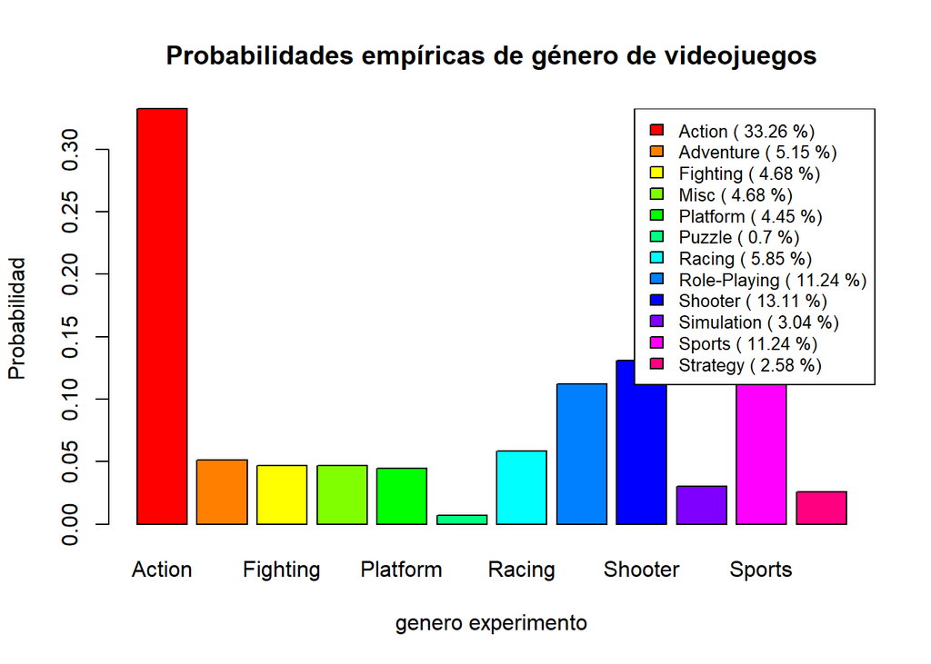

```r
# Calcular las probabilidades empíricas para la variable "Genre"
probabilidades_genre <- prop.table(table(juegos2015_2016$Genre))
generos <- names(probabilidades_genre)

#  gráfico para las probabilidades empíricas de "Genre"
barplot(probabilidades_genre, main = "Probabilidades empíricas de género de videojuegos", xlab = "genero experimento", ylab = "Probabilidad", col = rainbow(length(probabilidades_genre)), names.arg = generos)

# Leyenda
legend("topright", legend = paste(generos, "(", round(probabilidades_genre * 100, 2), "%)"), fill = rainbow(length(probabilidades_genre)), cex = 0.8)
```

variable: selecionar en el Experimento la data de videojuego estudiar y observar el dominio de genero videojuego

### 4.2 Probabilidad condicional

Ejemplo 1

1. Definimos nuestros eventos:

$A: \text{está definido como seleccionar un videojuego y que su crítica por un profesional sea mayor a 50}$ $B: \text{está definido como seleccionar un videojuego y que su crítica por los usuarios sea menor de 5 }$

2. Validando la independencia:
- Para el evento A:

```r
#Cantidad de videojuegos
t_videojuegos = nrow(juegos2015_2016)

# Cantidad de juegos que cumplen la condición

rep_SumA = sum(juegos2015_2016$Critic_Score > 50)

# Calculamos la probabilidad
prob_A= rep_SumA/ t_videojuegos

# Mostrar la probabilidad
prob_A
```

```
## [1] 0.9484778
```

El complemento de $A ' = 1 - p(A)$

- Para el evento B:

```r
table(juegos2015_2016$User_Score)
```

```
##
## 1.5 1.9   2 2.1 2.3 2.4 2.5 2.9   3 3.1 3.2 3.3 3.4 3.5 3.6 3.7 3.8   4 4.1 4.2
##   1   1   1   1   1   1   1   1   1   3   1   1   3   2   1   2   3   1   2   2
## 4.3 4.4 4.5 4.6 4.7 4.8 4.9   5 5.1 5.2 5.3 5.4 5.5 5.6 5.7 5.8 5.9   6 6.1 6.2
##   7   5   1   2   2   2   2   2   7   2   4   2   7   4   4   6   6   8   9  13
## 6.3 6.4 6.5 6.6 6.7 6.8 6.9   7 7.1 7.2 7.3 7.4 7.5 7.6 7.7 7.8 7.9   8 8.1 8.2
##  10   7   9  11   6  17  12   8  17   5  15  15   8  15  13  14  17  20  13  11
## 8.3 8.4 8.5 8.6 8.7 8.8 8.9   9 9.2 9.3 tbd
##   9   7  12   7   8   3   3   1   2   1   6
```

```r
# Contamos la cantidad de juegos que cumplen la condición que sean menor o igual que 5

rep_SumB = sum(juegos2015_2016$User_Score <= 5)

#Calculamos la probabilidad

prob_B = rep_SumB / t_videojuegos

prob_B
```

```
## [1] 0.1241218
```

El complemento de $B ' = 1 - p(B)$

- Comprobando la independecia de cada evento

$P(A ∩ B) = P(A). P(B)$

```r
#Intersección

Evento_A_Interseccion_B <- sum (juegos2015_2016$Critic_Score > 50 & juegos2015_2016$User_Score <= 5)
Pro_Evento_A_Interseccion_B <- Evento_A_Interseccion_B/t_videojuegos
Pro_Evento_A_Interseccion_B
```

```
## [1] 0.09367681
```

```r
#P(A).P(B)
prob_A*prob_B
```

```
## [1] 0.1177267
```

3. Teorema de Bayes:

$P(A|B) = P(A∩B) / P(B)$

```r
#prob_A
#prob_B

Pro_Evento_A_si_Evento_B <- Pro_Evento_A_Interseccion_B/prob_B
Pro_Evento_A_si_Evento_B
```

```
## [1] 0.754717
```

```r
Pro_Evento_B_si_Evento_A <- (Pro_Evento_A_Interseccion_B * prob_B)/prob_A

Pro_Evento_B_si_Evento_A
```

```
## [1] 0.01225894
```

Ejemplo 2

Eventos del experimento de la vase de datos de juegos: EVENTO A: Selecionar un juego con venta 0.01 millones norte america (dependiente) Evento B: Selecionar un juego que sea de ps4 (independiente) 1)vaidad independencia .P(A ∩ B)=P(A)*P(B) …. a11/T = TA/T* TB/T .P(A|B)=P(A)*(a11/TB=TA/T)

```r
tabla_frecuencia =  table(juegos2015_2016$Platform,juegos2015_2016$NA_Sales)
#P(A ∩ B)=P(A)*P(B)  .... a11/T = TA/T *TB/T
#16/66 =38/66 *29/66
38/66 *29/66  #SI CUMPLE
```

```
## [1] 0.2529844
```

```r
#.P(A|B)=P(A)*(a11/TB=TA/T)
#16/29 =38/66  # MARGEN DE ERROR DE 0.001%
38/66
```

```
## [1] 0.5757576
```

3)TEOREMA DE BAYES, cual es la probabilidad para que la venta de ps4 se hasta 0.01 P(B|A)= (P(A|B)P(B))/P(A)

```r
#PA=a11/tb *tb/t +a11/tb*tb/t
PA=(16/29)*(29/66)+(22/28)*(28/66)
#(P(A|B)P(B)):
P= (38/66)*(29/66)
#PA=a11/tb *tb/t +a11/tb*tb/t:
PA= P/PA
PA # el la p probabilidad de que el juego sea pese cuatro con venta de 0.01
```

```
## [1] 0.4393939
```

## 5. Variables

### 5.1 Variables discretas

#Variables discretas plataforma 1) Definimos que distribución se usara Aplicare tristibucion Binomial Mi variable es la plataforma de videojeugo, su exito es si la plataforma de videojuego es ps4, P(Exito) = f(#Ps4)/n,

```r
n=length(juegos2015_2016$Platform)# el numero de elementos en en plataforma

tabla_plataforma=table(juegos2015_2016$Platform)
ps4=tabla_plataforma[4]
probabilidad_de_exito = ps4/n # wa
probabilidad_de_exito # es la probabilidad que el juego sea de play 4
```

```
##       PS4
## 0.4074941
```

2. contruir variables aleatoria X :# numero de juego que pertenecen a la consola ps4 en el conjuto ‘n’

3)Identificar parametros

```r
# el numero de elementos en en plataforma
tabla_plataforma=table(juegos2015_2016$Platform[0:50])
ps4=tabla_plataforma[2]
probabilidad_de_exito = ps4/n # wa
print("probabilidad de exito para las consolas de ps4")
```

```
## [1] "probabilidad de exito para las consolas de ps4"
```

```r
probabilidad_de_exito # es la probpabilidad que el juego sea de play 4
```

```
##        PS4
## 0.07025761
```

```r
print("El numero de elementos es:")
```

```
## [1] "El numero de elementos es:"
```

```r
print(n)
```

```
## [1] 427
```

4)Construcion de densidad

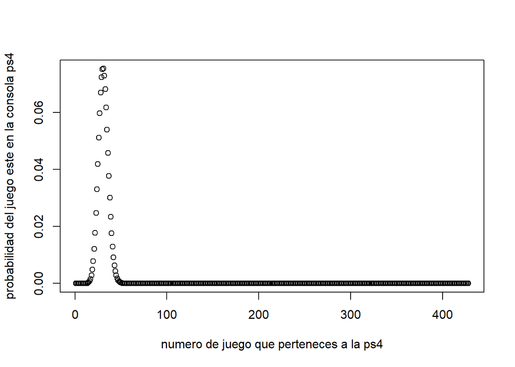

```r
n=427
p=probabilidad_de_exito


plot(dbinom(0:n,n,p),xlab ="numero de juego que perteneces a la ps4",ylab = "probabilidad del juego este en la consola ps4" )
```

5) validad propiedades

```r
#segunda version

# Definir los valores de la variable aleatoria y sus probabilidades correspondientes
valores = c(0:n) #tamaño de la muestra
proba_ps4 = dbinom(0:n,n,probabilidad_de_exito) #Probabilidad para cada persona

# Calculamos la esperanza , varianza , desviación estánda y coeficiente de variación
esperanza = sum(valores * proba_ps4)

varianza = sum(proba_ps4 * (valores - esperanza)^2)

desviacion_estandar = sqrt(varianza)

coeficiente_variacion = (desviacion_estandar / esperanza) * 100


esperanza
```

```
## [1] 30
```

```r
varianza
```

```
## [1] 27.89227
```

```r
coeficiente_variacion
```

```
## [1] 17.60438
```

#carlos

#### Variable discreta Género

1. Utilizaremos la variable Género y la asociaremos a la distribución binomial
2. Definimos nuestra variable aleatoria: **X**: es el número de videojuegos que pertenezcan a la categoría de **Shooter** en un conjunto “n”
3. Identificamos los parámetros:

$X \sim \text{bin}(p,n)$;

Siendo:

$p = P(E) : \text{la probabilidad de éxito que está definido como seleccionar un videojuego que sea de la categoría Shooter}$ $n=50 : \text{está definido como el tamaño de la muestra}$

4. Construimos la gráfica densidad:
- Hallamos la probabilidad de éxito

```r
n=50 #tamaño de la muestra (verificar)
table_shooter = table(juegos2015_2016$Genre[0:n]) #identificamos Shooter
shooter = table_shooter[8]

p_exito_shooter = shooter / n
p_exito_shooter
```

```
## Shooter
##    0.32
```

- Ahora que sabemos que la probabilidad es de **0.32**, procedemos a contruir la gráfica:

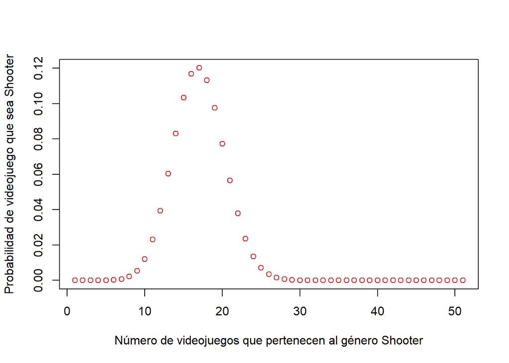

```r
plot(dbinom(0:n,n,p_exito_shooter),xlab = "Número de videojuegos que pertenecen al género Shooter", ylab = "Probabilidad de videojuego que sea Shooter",col="red")
```

5. Validando las propiedades de la variable aleatoria

```r
# Definir los valores de la variable aleatoria y sus probabilidades correspondientes
valores = c(0:50) #tamaño de la muestra
proba_shooter = dbinom(0:n,n,p_exito_shooter) #Probabilidad para cada persona

#Calculamos la esperanza , varianza , desviación estánda y coeficiente de variación

esperanza = sum(valores * proba_shooter)

varianza = sum(proba_shooter * (valores - esperanza)^2)

desviacion_estandar = sqrt(varianza)

coeficiente_variacion = (desviacion_estandar / esperanza) * 100


esperanza
```

```
## [1] 16
```

```r
varianza
```

```
## [1] 10.88
```

```r
coeficiente_variacion
```

```
## [1] 20.61553
```

6. Construyendo un ejemplo:

Electronic Entertainment Expo (E3) es la feria de videojuegos más importante del mundo y uno de los eventos de gaming más importantes, se desea conocer la probabilidad de que más del 50% de los asistentes elijan un videojuego y sea del género Shooter sabiendo que en esa feria asistieron 50 personas.

```r
# Probabilidad de éxito (probabilidad de que una persona elija un videojuego Shooter)
probabilidad_exito <- 0.32

# Número de asistentes a la E3
asistentes <- 50

# Calculamos la probabilidad utilizando la distribución binomial acumulativa
probabilidad <- 1 - pbinom(asistentes * 0.5, asistentes, probabilidad_exito)

#Resultado
print(probabilidad)
```

```
## [1] 0.002631415
```

#VARIABLES CONTINUAS ###EJEMPLO 1 VARIABLE CONTINUA